# **NLTK**

General features and capabilities:

1. Consist of algorithms such as tokenizing, part-of-speech tagging, stemming, sentiment analysis, topic segmentation, and named entity recognition.
2. Helps the computer to analysis, preprocess and understand text.

Useful data structures:

1. nltk.tokenize
2. nltk.probability
3. nltk.corpus
4. nltk.stem
5. nltk.stem.wordnet

Relevant to the construction of our dictionary:nltk.tokenize,nltk.corpus(removing stopWords),nltk.stem(PorterStemmer), nltk.stem.wordnet(WordNetLemmatizer).

## **TextBlob**

General features and capabilities:

1. Can be used for pre-processing.
2. Can be used to find sentiment of a document.
3. Such different tasks as:Part-of-speech Tagging ,Noun Phrase Extraction Sentiment Analysis, Tokenization ,Words Inflection and Lemmatization WordNet Integration, WordLists Spelling Correction, Get Word and Noun Phrase Frequencies, Parsing, n-grams and etc.

Useful data structures: TextBlob. Relevant to the construction of our dictionary:lets define blob = TextBlob(text) and for tockenization of words use blob.words,for lemmatization use blob.lemmatize(),for definition use blob.definitions,for spelling correction use blob.correct(),

### **spaCy**

General features and capabilities:

1. Designed specifically for production use.
2. Can be used to build information extraction or natural language understanding systems, or to pre-process text for deep learning.
3. Include features as Part-of-speech tags,Syntactic dependencies,Named Entities and etc.

Useful data structures:

1. Language class-A text-processing pipeline.Contains the shared vocabulary,language data, optional binary weights,processing pipeline .
2. Vocab-storage class for vocabulary and other data shared across a language.
3. Doc-container for accessing linguistic annotations.

Relevant to the construction of our dictionary: all of them.

We will use dataset from previous lab about tweets.

```python
import pandas as pd

table=pd.read_csv('trainTwitter.csv')
table.head()
```

|  | id | label | tweet |
| --- | --- | --- | --- |
| 0 | 1 | 0 | @user when a father is dysfunctional and is s... |
| 1 | 2 | 0 | @user @user thanks for #lyft credit i can't us... |
| 2 | 3 | 0 | bihday your majesty |
| 3 | 4 | 0 | #model i love u take with u all the time in ... |
| 4 | 5 | 0 | factsguide: society now #motivation |

### All tasks with NLTK

```python
import nltk
```

```python
from nltk.tokenize import sent_tokenize
from nltk.tokenize import word_tokenize
from nltk.stem.wordnet import WordNetLemmatizer
from nltk.stem.porter import PorterStemmer
#-------------------------------------------------------------------------------------------------------------------------------
SentenceList=list()
tweetCol=table['tweet']
lemmatizer  = WordNetLemmatizer()
stem = PorterStemmer()
#-------------------------------------------------------------------------------------------------------------------------------
def lemm(tweet):
    word_list = nltk.word_tokenize(tweet)
    lemmatized_output = ' '.join([lemmatizer.lemmatize(w) for w in word_list])
    return lemmatized_output
def Stm(tweet):
    stmlst=list()
    word_list = nltk.word_tokenize(tweet)
    for w in word_list:
        stmlst.append(stem.stem(w))
    stem_output = ' '.join(stmlst)
    return stem_output
#-------------------------------------------------------------------------------------------------------------------------------
def makingRow(tweet):
    def check_hash(w):
        for s in w:
            return s[0]!='@' and s[0]!='#'
    result=list()
    words = tweet.split()
    clean_words = list(filter(check_hash, words)) # clean hash from words list
    clean_str=" ".join(clean_words)
    wordTokens=word_tokenize(clean_str)
    #tweetAppend
    result.append(clean_str)
    #tokenization
    result.append(sent_tokenize(clean_str))
    result.append(word_tokenize(clean_str))
    #lemmatization&stemming
    result.append(lemm(clean_str))
    result.append(Stm(clean_str))
    return result
#-------------------------------------------------------------------------------------------------------------------------------
def mainFunc():
    i=0
    while(i<len(tweetCol)):
        current=makingRow(tweetCol[i])
        SentenceList.append(current)
        i=i+1
#-------------------------------------------------------------------------------------------------------------------------------
mainFunc()
df1 = pd.DataFrame(SentenceList,columns=['Tweet','After Sentence tokenization','After Word tokenization',
                                                    'After Lemmatization','After Stemming'])

df1.head()
```

|  | Tweet | After Sentence tokenization | After Word tokenization | After Lemmatization | After Stemming |
| --- | --- | --- | --- | --- | --- |
| 0 | when a father is dysfunctional and is so selfi... | [when a father is dysfunctional and is so self... | [when, a, father, is, dysfunctional, and, is, ... | when a father is dysfunctional and is so selfi... | when a father is dysfunct and is so selfish he... |
| 1 | thanks for credit i can't use cause they don't... | [thanks for credit i can't use cause they don'... | [thanks, for, credit, i, ca, n't, use, cause, ... | thanks for credit i ca n't use cause they do n... | thank for credit i ca n't use caus they do n't... |
| 2 | bihday your majesty | [bihday your majesty] | [bihday, your, majesty] | bihday your majesty | bihday your majesti |
| 3 | i love u take with u all the time in urð±!!!... | [i love u take with u all the time in urð±!!... | [i, love, u, take, with, u, all, the, time, in... | i love u take with u all the time in urð± ! ... | i love u take with u all the time in urð± ! ... |
| 4 | factsguide: society now | [factsguide: society now] | [factsguide, :, society, now] | factsguide : society now | factsguid : societi now |

```python
from nltk.corpus import wordnet
#Synonyms
#Let's see how nltk works with it on example of first tweet
tweet1=df1['After Word tokenization'][0]

data=list()
i=0

def synFync(t):
    words=list()
    temp=list()
    temp.append(t)
    for syn in wordnet.synsets(t):
        for l in syn.lemmas():
            words.append(l.name())
    words=",".join(words)
    temp.append(words)
    return temp

while(i<len(tweet1)):
    current=synFync(tweet1[i])
    data.append(current)
    i=i+1

df2=pd.DataFrame(data,columns=['Word','Synonyms'])
print("Current sentence: " + df1['Tweet'][0])
df2.head()
```

```
Current sentence: when a father is dysfunctional and is so selfish he drags his kids into his dysfunction.
```

|  | Word | Synonyms |
| --- | --- | --- |
| 0 | when |  |
| 1 | a | angstrom,angstrom_unit,A,vitamin_A,antiophthalmic_factor,axerophthol,A,deoxyadenosine_... |
| 2 | father | father,male_parent,begetter,forefather,father,sire,Father,Padre,Church_Father,Father_o... |
| 3 | is | be,be,be,exist,be,be,equal,be,constitute,represent,make_up,comprise,be,be,follow,embod... |
| 4 | dysfunctional | dysfunctional,dysfunctional,nonadaptive |

```python
#WSD
from nltk.wsd import lesk
from nltk.tokenize import word_tokenize
result=list()
i=0
currentT=word_tokenize(df1['Tweet'][0])

def wsd(t):
    temp=list()
    res=lesk(word_tokenize(df1['Tweet'][0]),t)
    if res is not None:
        temp.append(res.definition())
    else:
        temp.append('None')
    deff=" ".join(temp)
    return deff

while(i<len(currentT)):
    result.append(wsd(currentT[i]))
    i=i+1

print("Current sentence: " + df1['Tweet'][0])
tweet2=df1['After Word tokenization'][0]
pd.set_option('max_colwidth', 90)
df2['WSD']=result
df2.head()
```

```
Current sentence: when a father is dysfunctional and is so selfish he drags his kids into his dysfunction.
```

|  | Word | Synonyms | WSD |
| --- | --- | --- | --- |
| 0 | when |  | None |
| 1 | a | angstrom,angstrom_unit,A,vitamin_A,antiophthalmic_factor,axerophthol,A,deoxyadenosine_... | one of the four nucleotides used in building DNA; all four nucleotides have a common p... |
| 2 | father | father,male_parent,begetter,forefather,father,sire,Father,Padre,Church_Father,Father_o... | `Father' is a term of address for priests in some churches (especially the Roman Catho... |
| 3 | is | be,be,be,exist,be,be,equal,be,constitute,represent,make_up,comprise,be,be,follow,embod... | represent, as of a character on stage |
| 4 | dysfunctional | dysfunctional,dysfunctional,nonadaptive | (of a trait or condition) failing to serve an adjustive purpose |

```python
#Named Entity Recognition (NER)
from nltk.tag import pos_tag
from nltk.chunk import tree2conlltags
#We tag each word with their respective Part-of-Speech tags using pos_tag()
postags=pos_tag(currentT)
i=0
res1=list()
res2=list()
#Now we wiil use ne_chunk() to recognize each named entity in the sentence.
chunks=nltk.ne_chunk(postags,binary=False)
iob_tagged = tree2conlltags(chunks)
print("Current sentence: " + df1['Tweet'][0])
print("B-{CHUNK_TYPE} – for the word in the Beginning chunk")
print("I-{CHUNK_TYPE} – for words Inside the chunk")
print("O – Outside any chunk")

while(i<len(iob_tagged)):
    res1.append(list(iob_tagged[i][1]))
    res2.append(iob_tagged[i][2])
    i=i+1

df2['PosTag']=res1
df2['CHUNK_TYPE']=res2
df2.head()
```

```
Current sentence: when a father is dysfunctional and is so selfish he drags his kids into his dysfunction.
B-{CHUNK_TYPE} – for the word in the Beginning chunk
I-{CHUNK_TYPE} – for words Inside the chunk
O – Outside any chunk
```

|  | Word | Synonyms | WSD | PosTag | CHUNK_TYPE |
| --- | --- | --- | --- | --- | --- |
| 0 | when |  | None | [W, R, B] | O |
| 1 | a | angstrom,angstrom_unit,A,vitamin_A,antiophthalmic_factor,axerophthol,A,deoxyadenosine_... | one of the four nucleotides used in building DNA; all four nucleotides have a common p... | [D, T] | O |
| 2 | father | father,male_parent,begetter,forefather,father,sire,Father,Padre,Church_Father,Father_o... | `Father' is a term of address for priests in some churches (especially the Roman Catho... | [N, N] | O |
| 3 | is | be,be,be,exist,be,be,equal,be,constitute,represent,make_up,comprise,be,be,follow,embod... | represent, as of a character on stage | [V, B, Z] | O |
| 4 | dysfunctional | dysfunctional,dysfunctional,nonadaptive | (of a trait or condition) failing to serve an adjustive purpose | [J, J] | O |

Remarks:

1. There is no function in nltk for spelling correction.
2. There is no function in nltk for work with Acronym/Abbreviations. It may be done by clasic python depends on purpose.

### All tasks with TextBlob

```python
#Tokenization
from textblob import TextBlob
curTweet=df1['Tweet'][34]

my_sentence = TextBlob(curTweet)
res=my_sentence.words
print("Current sentence: " + curTweet+" And Below his tokenization: ")
print(res)
print("")
print("Current sentence after spelling correction: ")
correct=my_sentence.correct()
print(correct)
```

```
Current sentence: it's unbelievable that in the 21st century we'd need something like this. again. And Below his tokenization:
['it', "'s", 'unbelievable', 'that', 'in', 'the', '21st', 'century', 'we', "'d", 'need', 'something', 'like', 'this', 'again']

Current sentence after spelling correction:
it's unbelievable that in the must century we'd need something like this. again.
```

```python
#Lemmatization
from textblob import Word
sentence = TextBlob(curTweet)
tokens=sentence.words
temp=list()

for t in tokens:
    temp.append(Word(t).lemmatize())

df3=pd.DataFrame(tokens,columns=['Tokens'])
df3['Lemmatization']=temp
df3.head()
```

|  | Tokens | Lemmatization |
| --- | --- | --- |
| 0 | it | it |
| 1 | 's | 's |
| 2 | unbelievable | unbelievable |
| 3 | that | that |
| 4 | in | in |

```python
#synonyms
from textblob import TextBlob
from textblob import Word
tokenCol=df3['Tokens']
synonyms = set()
res=list()

for t in tokenCol:
    text_word = Word(t)
    for synset in text_word.synsets:
        for lemma in synset.lemmas():
            synonyms.add(lemma.name())
    if len(synonyms)==0:
        res.append('No Synonyms')
    else:
        res.append(','.join(list(synonyms)))
    synonyms.clear()

df3['Synonyms']=res
print("Current sentence: " + curTweet)
df3.head()
```

```
Current sentence: it's unbelievable that in the 21st century we'd need something like this. again.
```

|  | Tokens | Lemmatization | Synonyms |
| --- | --- | --- | --- |
| 0 | it | it | IT,information_technology |
| 1 | 's | 's | No Synonyms |
| 2 | unbelievable | unbelievable | unconvincing,unbelievable,improbable,unlikely,incredible |
| 3 | that | that | No Synonyms |
| 4 | in | in | IN,indium,Hoosier_State,In,atomic_number_49,inch,inward,Indiana,inwards,in |

```python
#NER
from nltk.chunk import tree2conlltags
i=0
res1=list()
res2=list()

chunks=my_sentence.tags
iob_tagged = tree2conlltags(chunks)

while(i<len(iob_tagged)):
    res1.append(list(iob_tagged[i][1]))
    res2.append(iob_tagged[i][2])
    i=i+1

df3['PosTag']=res1
df3['CHUNK_TYPE']=res2

print("Current sentence: " + curTweet)
print("B– for the word in the Beginning chunk")
print("I– for words Inside the chunk")
print("O – Outside any chunk")
df3.head()
```

```
Current sentence: it's unbelievable that in the 21st century we'd need something like this. again.
B– for the word in the Beginning chunk
I– for words Inside the chunk
O – Outside any chunk
```

|  | Tokens | Lemmatization | Synonyms | PosTag | CHUNK_TYPE |
| --- | --- | --- | --- | --- | --- |
| 0 | it | it | information_technology,IT | [P, R, P] | O |
| 1 | 's | 's | No Synonyms | [V, B, Z] | O |
| 2 | unbelievable | unbelievable | incredible,unbelievable,unconvincing,unlikely,improbable | [J, J] | O |
| 3 | that | that | No Synonyms | [I, N] | O |
| 4 | in | in | In,inwards,Indiana,Hoosier_State,atomic_number_49,in,indium,IN,inch,inward | [I, N] | O |

Remarks:

1. There is no feature in TextBlob for performing Stemming.
2. There is no feature in TextBlob for detection of acronym/abbreviations
3. There is no feature in TextBlob for WSD(Word sense disambiguation).

### All tasks with spaCy

```python
#Tokenization
import spacy
sp = spacy.load('en_core_web_md')
curTweet=df1['Tweet'][50]

tokens=sp(curTweet)
print("Current sentence: " + curTweet)
print(f"Tokens- >[{tokens}]")
```

```
Current sentence: getting ready 2 remove the victums frm
Tokens- >[getting ready 2 remove the victums frm]
```

```python
#lemmatization
import spacy

temp=list()
for t in tokens:
    temp.append(t.lemma_)

print("Current sentence: " + curTweet)
df4=pd.DataFrame(tokens,columns=['Tokens'])
df4['Lemmatization']=temp
df4.head()
```

```
Current sentence: getting ready 2 remove the victums frm
```

|  | Tokens | Lemmatization |
| --- | --- | --- |
| 0 | getting | get |
| 1 | ready | ready |
| 2 | 2 | 2 |
| 3 | remove | remove |
| 4 | the | the |

```python
#ENR
text="The Indian Space Research Organisation or is the national space agency of India, headquartered in Bengaluru. It operates under Department of Space which is directly overseen by the Prime Minister of India while Chairman of ISRO acts as executive of DOS as well."
text1= sp(text)

for word in text1.ents:
    print(word.text,word.label_)

print("===Explanations===")
print("ORG-"+spacy.explain("ORG"))
print("GPE-"+spacy.explain("GPE"))
```

```
The Indian Space Research Organisation ORG
India GPE
Bengaluru GPE
Department of Space ORG
India GPE
ISRO ORG
===Explanations===
ORG-Companies, agencies, institutions, etc.
GPE-Countries, cities, states
```

Remarks:

1. There is no feature in Spacy for performing Stemming.
2. There is no feature in Spacy for detection of acronym/abbreviations
3. There is no feature in Spacy for WSD(Word sense disambiguation).
4. There is no feature in Spacy for finding synonyms.

### Building Dictionary

```python
import re
# Import clean tweets
temp = pd.read_csv('clean-tweets.csv')
nan_value = float("NaN")
temp.replace("", nan_value, inplace=True)
temp.dropna(subset = ['After'], inplace=True)
clean_tweets = temp['After']
original_tweets = [] # Used by boolean find functions
tweetsPart2 = list() # Used to build boolean matrix and inversed index
pattern = r'[ðâï¾¼½µãªº]'

# Tokenize and calculate freq
tweet_dict = {}
for tweet in clean_tweets:
    clean_tweet = re.sub(pattern, '', tweet)
    original_tweets.append(clean_tweet)
    token = clean_tweet.split()
    tweetsPart2.append([stem.stem(t) for t in token])
    for word in token:
        if word in tweet_dict:
            tweet_dict[word] += 1;
        else:
            tweet_dict[word] = 1;
print(tweet_dict)
```

```
{'father': 131, 'dysfunctional': 1, 'selfish': 7, 'drags': 4, 'kids': 143, 'dysfunction': 2, 'thanks': 269, 'credit': 15, 'cant': 811, 'use': 115, 'cause': 72, 'dont': 729, 'offer': 26, 'wheelchair': 2, 'vans': 1, 'pdx': 1, 'bihday': 572, 'majesty': 7, 'love': 1207, 'u': 1138, 'take': 615, 'time': 1…
```

```python
#Build table from dictinary and create frequncy column
dict_table = pd.DataFrame(tweet_dict.items(),columns=['Word','Frequency'])
dict_table.head(10)
```

|  | Word | Frequency |
| --- | --- | --- |
| 0 | father | 131 |
| 1 | dysfunctional | 1 |
| 2 | selfish | 7 |
| 3 | drags | 4 |
| 4 | kids | 143 |
| 5 | dysfunction | 2 |
| 6 | thanks | 269 |
| 7 | credit | 15 |
| 8 | cant | 811 |
| 9 | use | 115 |

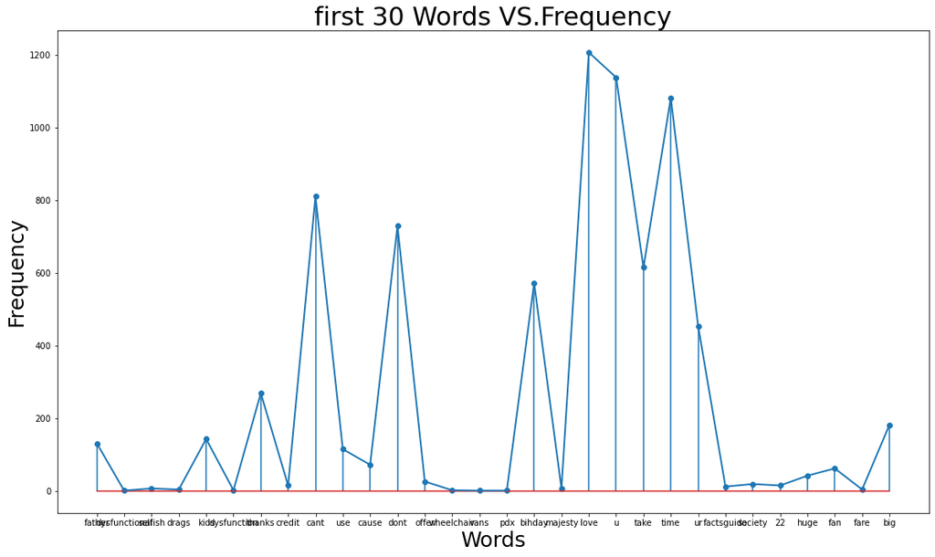

```python
import matplotlib.pyplot as plt

x = dict_table['Word'][0:30]
y = dict_table['Frequency'][0:30]
fig, ax = plt.subplots()
fig.set_size_inches(18.5, 10.5)
ax.stem(x, y)

ax.plot(x, y, linewidth=2.0)
plt.title('first 30 Words VS.Frequency', fontsize=30)
ax.set_xlabel('Words', fontsize=25)
ax.set_ylabel('Frequency', fontsize=25)
plt.show()
```

```python
#Lemmatization
bagOfWords = dict_table['Word']
temp=list()
for t in bagOfWords:
    temp.append(Word(t).lemmatize())

lemData=pd.DataFrame(bagOfWords,columns=['Word'])
lemData['Lemmatization']=temp
lemData.head(15)
```

|  | Word | Lemmatization |
| --- | --- | --- |
| 0 | father | father |
| 1 | dysfunctional | dysfunctional |
| 2 | selfish | selfish |
| 3 | drags | drag |
| 4 | kids | kid |
| 5 | dysfunction | dysfunction |
| 6 | thanks | thanks |
| 7 | credit | credit |
| 8 | cant | cant |
| 9 | use | use |
| 10 | cause | cause |
| 11 | dont | dont |
| 12 | offer | offer |
| 13 | wheelchair | wheelchair |
| 14 | vans | van |

```python
# Stemming
stem = PorterStemmer()
temp=list()
for t in bagOfWords:
    temp.append(stem.stem(t))
lemData['Stemming']=temp
lemData.head(15)
```

|  | Word | Lemmatization | Stemming |
| --- | --- | --- | --- |
| 0 | father | father | father |
| 1 | dysfunctional | dysfunctional | dysfunct |
| 2 | selfish | selfish | selfish |
| 3 | drags | drag | drag |
| 4 | kids | kid | kid |
| 5 | dysfunction | dysfunction | dysfunct |
| 6 | thanks | thanks | thank |
| 7 | credit | credit | credit |
| 8 | cant | cant | cant |
| 9 | use | use | use |
| 10 | cause | cause | caus |
| 11 | dont | dont | dont |
| 12 | offer | offer | offer |
| 13 | wheelchair | wheelchair | wheelchair |
| 14 | vans | van | van |

```python
# Here we try to build one on top of another , first lematization after stemming than switch and see results
stem = PorterStemmer()
temp1=list()
temp2=list()
for t in bagOfWords:
    # lematization then stemming
    wordL = Word(t).lemmatize()
    wordS = stem.stem(wordL)
    temp1.append(wordS)
    #stemming them lematization
    wordS = stem.stem(t)
    wordL = Word(wordS).lemmatize()
    temp2.append(wordL)
lemData=pd.DataFrame(bagOfWords,columns=['Word'])
lemData['L then S']=temp1
lemData['S them L'] = temp2
lemData.head(15)
```

|  | Word | L then S | S them L |
| --- | --- | --- | --- |
| 0 | father | father | father |
| 1 | dysfunctional | dysfunct | dysfunct |
| 2 | selfish | selfish | selfish |
| 3 | drags | drag | drag |
| 4 | kids | kid | kid |
| 5 | dysfunction | dysfunct | dysfunct |
| 6 | thanks | thank | thank |
| 7 | credit | credit | credit |
| 8 | cant | cant | cant |
| 9 | use | use | use |
| 10 | cause | caus | caus |
| 11 | dont | dont | dont |
| 12 | offer | offer | offer |
| 13 | wheelchair | wheelchair | wheelchair |
| 14 | vans | van | van |

## **חלק ב' - ייצוג המסמכים והשאילתה :**

```python
import time
# Prepare dictinary and tweets
smallBag = tweetsPart2[0:100]
biggerBag = tweetsPart2[0:1000]
# Build small and larger dict (choose most frequent word)
dict_table = dict_table.sort_values(by='Frequency', ascending=False)
smallDict= [stem.stem(t) for t in dict_table['Word'][0:100]]
bigDict = [stem.stem(t) for t in dict_table['Word']]
print('Example of tweet', smallBag[0])
print('Example of dictinary', bigDict[0:10])
```

```
Example of tweet ['father', 'dysfunct', 'selfish', 'drag', 'kid', 'dysfunct']
Example of dictinary ['day', 'amp', 'happi', 'love', 'im', 'u', 'time', 'like', 'today', 'new']
```

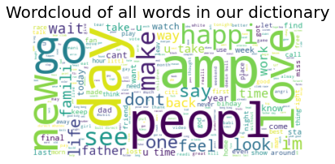

```python
from wordcloud import WordCloud
import matplotlib.pyplot as plt

tweets_str=''
for b in biggerBag:
    tweets_str+= ', '.join(b)

My_wc = WordCloud(
    background_color='white',
    max_words=2000
)
My_wc.generate(tweets_str)
plt.imshow(My_wc, interpolation='bilinear')
plt.axis('off')
plt.title('Wordcloud of all words in our dictionary', fontsize=20)

plt.show()
```

Meaning for us: the bigger and bolder the word appears, the more often it’s mentioned within a given text and the more important it is. Before lematization and other actions with the words all of them were reduced to their root. As example: daily to day, news to new and etc.

```python
start = time.time()
# Build small Bollean Matrix for 100 tweets
boolean_matrix = {}
# go over each word in dictinary to build row
for word in smallDict:
    matrix_row = list()
    # go over all tweet in tweets bag and check if contain word from dictinary
    for tweet in smallBag:
        if word in tweet:
            matrix_row.append(1)
        else:
            matrix_row.append(0)
    boolean_matrix[word]=matrix_row

# Bulding small dictinary for 100 tweets
tweetDict = {}
for i in range(len(smallBag)):
    strIndex = 't'+str(i)
    tweetDict[strIndex]=original_tweets[i]
end = time.time()
print('Time to build such matrix and dictinary ' + str(end - start))
#Show all in one table
matrixColumns = []
matrixColumns = list(tweetDict.keys())
matrix_table = pd.DataFrame.from_dict(boolean_matrix, orient='index',columns=matrixColumns)
matrix_table.head(10)
```

```
Time to build such matrix and dictinary 0.002989053726196289
```

|  | t0 | t1 | t2 | t3 | t4 | t5 | t6 | t7 | t8 | t9 | ... | t90 | t91 | t92 | t93 | t94 | t95 | t96 | t97 | t98 | t99 |
| --- | --- | --- | --- | --- | --- | --- | --- | --- | --- | --- | --- | --- | --- | --- | --- | --- | --- | --- | --- | --- | --- |
| day | 0 | 0 | 0 | 0 | 0 | 0 | 0 | 0 | 0 | 0 | ... | 0 | 0 | 0 | 1 | 0 | 0 | 1 | 0 | 0 | 0 |
| amp | 0 | 0 | 0 | 0 | 0 | 0 | 0 | 0 | 0 | 0 | ... | 0 | 0 | 0 | 0 | 0 | 0 | 0 | 0 | 0 | 0 |
| happi | 0 | 0 | 0 | 0 | 0 | 0 | 0 | 0 | 0 | 0 | ... | 0 | 0 | 0 | 0 | 0 | 0 | 0 | 0 | 0 | 0 |
| love | 0 | 0 | 0 | 1 | 0 | 0 | 0 | 0 | 1 | 0 | ... | 0 | 0 | 1 | 0 | 1 | 0 | 0 | 0 | 0 | 0 |
| im | 0 | 0 | 0 | 0 | 0 | 0 | 0 | 0 | 0 | 1 | ... | 0 | 0 | 0 | 0 | 0 | 0 | 0 | 0 | 0 | 0 |
| u | 0 | 0 | 0 | 1 | 0 | 0 | 0 | 0 | 0 | 0 | ... | 0 | 0 | 0 | 0 | 1 | 0 | 0 | 0 | 0 | 0 |
| time | 0 | 0 | 0 | 1 | 0 | 0 | 0 | 0 | 0 | 0 | ... | 0 | 0 | 0 | 0 | 1 | 0 | 0 | 0 | 0 | 0 |
| like | 0 | 0 | 0 | 0 | 0 | 0 | 0 | 0 | 0 | 0 | ... | 0 | 0 | 0 | 0 | 0 | 0 | 0 | 0 | 0 | 0 |
| today | 0 | 0 | 0 | 0 | 0 | 0 | 0 | 0 | 0 | 0 | ... | 0 | 0 | 0 | 0 | 0 | 0 | 0 | 0 | 0 | 0 |
| new | 0 | 0 | 0 | 0 | 0 | 0 | 0 | 0 | 0 | 0 | ... | 0 | 0 | 0 | 0 | 0 | 0 | 0 | 0 | 0 | 0 |

10 rows × 100 columns

```python
start = time.time()
# Build all words Bollean Matrix for 1000 tweets
boolean_matrix = {}
# go over each word in dictinary to build row
for word in bigDict:
    matrix_row = list()
    # go over all tweet in tweets bag and check if contain word from dictinary
    for tweet in biggerBag:
        if word in tweet:
            matrix_row.append(1)
        else:
            matrix_row.append(0)
    boolean_matrix[word]=matrix_row

# Bulding dictinary for 1000 tweets
tweetDict = {}
for i in range(len(biggerBag)):
    strIndex = 't'+str(i)
    tweetDict[strIndex]=original_tweets[i]

end = time.time()
print('Time to build such matrix and dictinary ' + str(end - start))
#Show all in one table
matrixColumns = []
matrixColumns = list(tweetDict.keys())
matrix_table = pd.DataFrame.from_dict(boolean_matrix, orient='index',columns=matrixColumns)
matrix_table.head(10)
```

```
Time to build such matrix and dictinary 5.720016002655029
```

|  | t0 | t1 | t2 | t3 | t4 | t5 | t6 | t7 | t8 | t9 | ... | t990 | t991 | t992 | t993 | t994 | t995 | t996 | t997 | t998 | t999 |
| --- | --- | --- | --- | --- | --- | --- | --- | --- | --- | --- | --- | --- | --- | --- | --- | --- | --- | --- | --- | --- | --- |
| day | 0 | 0 | 0 | 0 | 0 | 0 | 0 | 0 | 0 | 0 | ... | 0 | 0 | 0 | 0 | 0 | 1 | 0 | 0 | 0 | 0 |
| amp | 0 | 0 | 0 | 0 | 0 | 0 | 0 | 0 | 0 | 0 | ... | 0 | 0 | 0 | 0 | 0 | 0 | 0 | 0 | 0 | 0 |
| happi | 0 | 0 | 0 | 0 | 0 | 0 | 0 | 0 | 0 | 0 | ... | 0 | 0 | 0 | 0 | 0 | 0 | 0 | 1 | 0 | 0 |
| love | 0 | 0 | 0 | 1 | 0 | 0 | 0 | 0 | 1 | 0 | ... | 0 | 0 | 0 | 0 | 0 | 0 | 0 | 0 | 0 | 0 |
| im | 0 | 0 | 0 | 0 | 0 | 0 | 0 | 0 | 0 | 1 | ... | 0 | 0 | 0 | 0 | 0 | 0 | 0 | 0 | 0 | 0 |
| u | 0 | 0 | 0 | 1 | 0 | 0 | 0 | 0 | 0 | 0 | ... | 0 | 0 | 0 | 0 | 0 | 0 | 0 | 1 | 0 | 0 |
| time | 0 | 0 | 0 | 1 | 0 | 0 | 0 | 0 | 0 | 0 | ... | 0 | 0 | 0 | 0 | 0 | 0 | 0 | 0 | 0 | 0 |
| like | 0 | 0 | 0 | 0 | 0 | 0 | 0 | 0 | 0 | 0 | ... | 0 | 0 | 0 | 0 | 0 | 0 | 0 | 0 | 0 | 0 |
| today | 0 | 0 | 0 | 0 | 0 | 0 | 0 | 0 | 0 | 0 | ... | 0 | 0 | 0 | 0 | 0 | 1 | 0 | 0 | 0 | 0 |
| new | 0 | 0 | 0 | 0 | 0 | 0 | 0 | 0 | 0 | 0 | ... | 0 | 0 | 0 | 0 | 0 | 0 | 0 | 0 | 0 | 0 |

10 rows × 1000 columns

```python
#Build Boolean Function To search Words
def magic_find(q):

    if q in boolean_matrix:
        # find list of 0 and 1 for queue
        word_value = boolean_matrix[q]
        # build list of keys from list of 0 and 1
        tweet_keys = []
        for i in range(len(word_value)):
            if word_value[i] == 1:
                # build key depend on index
                tweet_keys.append('t'+str(i))
        # get tweets using list of relevant keys that found in prev step
        tweets = []
        for k in tweet_keys:
            if k in tweetDict:
                tweets.append(tweetDict[k])
        return tweets


def clean_query(q):
    token = q.split()
    return [stem.stem(t) for t in token]

def find_query(q ,mode):

    query = clean_query(q)

    start = time.time()
    modes = ['and','or','not']
    result = []
    if mode not in modes:
        return result
    else:
        if mode == 'and':
            for w in query:
                result.append(magic_find(w))
        elif mode == 'or':
            for w in query:
                temp = magic_find(w)
                if len(result) == 0:
                    result.append(temp)
                else:
                    break

    end = time.time()
    print('Time to find queary in boolean matrix 1000 tweets ' + str(end - start))
    print(' ')
    print('Tweets')
    print(result)

find_query('day father','or')
```

```
Time to find queary in boolean matrix 1000 tweets 0.0009970664978027344

Tweets
[['product day happy man tool whos time open amp drink', 'happy fathers day ', 'life social networking embrace day', 'happy fathers day mr rayos', 'celebrate every man played fatherly role fathers day', 'ill always hope one day ill get hug dont think gon na happen anytime soon', 'day edwardsville pe…
```

```python
!pip3 install hashedindex
```

```python
#Build Inverted Index
import hashedindex
start = time.time()
index = hashedindex.HashedIndex()
# build inverted index
for i in range(0, len(smallBag)):
    for word in smallBag[i]:
        index.add_term_occurrence(word, 't'+str(i))
#build aditional data types
words = list(index.terms())
counts = [dict(index[x]) for x in words]
end = time.time()
print('Time to build such inversed index' + str(end - start))
index.items()
```

```
Time to build such inversed index0.001993894577026367
```

[output not shown]

[output cut: 375 more lines]

[output not shown]

```python
#Build Inverted Index
start = time.time()
index = hashedindex.HashedIndex()

# build inverted index
for i in range(0, len(biggerBag)):
    for word in biggerBag[i]:
        index.add_term_occurrence(word, 't'+str(i))
#build aditional data types
words = list(index.terms())
counts = [dict(index[x]) for x in words]
end = time.time()
print('Time to build such inversed index ' + str(end - start))
index.items()
```

```
Time to build such inversed index 0.028922557830810547
```

[output not shown]

[output cut: 3008 more lines]

[output not shown]

```python
#Build Boolean Function To search Words
def magic_find2(q):
    tweets = []
    if q in words:
        # find dict of documents and frequency
        word_value = dict(index[q])
        # build list of keys prev step
        tweet_keys = word_value.keys()
        for k in tweet_keys:
            if k in tweetDict:
                tweets.append(tweetDict[k])
        return tweets

def clean_query(q):
    token = q.split()
    return [stem.stem(t) for t in token]

def find_query(q ,mode):

    query = clean_query(q)

    start = time.time()
    modes = ['and','or','not']
    result = []
    if mode not in modes:
        return result
    else:
        if mode == 'and':
            for w in query:
                result.append(magic_find(w))
        elif mode == 'or':
            for w in query:
                temp = magic_find(w)
                if len(result) == 0:
                    result.append(temp)
                else:
                    break

    end = time.time()
    print('Time to find queary in boolean matrix 1000 tweets ' + str(end - start))
    print(' ')
    print('Tweets')
    print(result)

find_query('day father','or')
```

```
Time to find queary in boolean matrix 1000 tweets 0.0

Tweets
[['product day happy man tool whos time open amp drink', 'happy fathers day ', 'life social networking embrace day', 'happy fathers day mr rayos', 'celebrate every man played fatherly role fathers day', 'ill always hope one day ill get hug dont think gon na happen anytime soon', 'day edwardsville pe…
```

### **חלק ג' - סיכום :**

Boolean Matrix simplier to implement and time is taking for small amount of docs to build and calculate is prety fast , but with docs amount increasing problem start to show up. On the other hand build inversed index could be challenging but it works a lot better and faster with big data sets So its depends on problem that given and amount of documents to calculate/

[figure not shown]

```python
import matplotlib.pyplot as plt
#number of words:run time for creating inverted index
invIndex_time=dict()

def calc_runTime(num):
    start = time.time()
    index = hashedindex.HashedIndex()

    for i in range(0, num):
        for word in biggerBag[i]:
            index.add_term_occurrence(word, 't'+str(i))

    words = list(index.terms())
    counts = [dict(index[x]) for x in words]
    end = time.time()
    return end - start

invIndex_time[200]=calc_runTime(200)
invIndex_time[400]=calc_runTime(200)
invIndex_time[600]=calc_runTime(200)
invIndex_time[800]=calc_runTime(800)
invIndex_time[1000]=calc_runTime(1000)

x=invIndex_time.keys()
y=invIndex_time.values()
fig, ax = plt.subplots()
fig.set_size_inches(16.5, 10.5)
ax.plot(x, y, linewidth=2.0)
plt.title('RunTime for building Inverted Index VS. Ammount of data', fontsize=30)
ax.set_xlabel('Number of words', fontsize=25)
ax.set_ylabel('Run time for creating inverted index', fontsize=25)
```